# classes vs environment - R Notebook

For now envrionmental data was obtained by outputting the sample info from 4a_megaTwinDeepSummariesVclasses with the P class info attached, and using arcGIS to sample the rasters used in the seaPen study. This can be redone with the best available data after Margaret has collected it and the sampling can be performed in R.

#Libraries

```r
library(ggplot2)
library(raster)
library(rgdal)
library(tibble)
library(dplyr)
library(ggbiplot)
```

# Load env rasters

```r
pathEnv <- "F:/Data/PredictorVariables/TOPCOPIES/CorrectNames/"

sp.env <- stack(paste0(pathEnv,"Bathy.tif"),
            paste0(pathEnv,"Cspd_Mx.tif"),
            paste0(pathEnv,"Ice_Av.tif"),
            paste0(pathEnv,"Salt_Rng.tif"),
            paste0(pathEnv,"Sed_Grav.tif"),
            paste0(pathEnv,"Sed_Mud.tif"),
            paste0(pathEnv,"Sed_Sand.tif"),
            paste0(pathEnv,"Slope_3.tif"),
            paste0(pathEnv,"T_Rng.tif"),
            paste0(pathEnv,"TPI_f3.tif"),
            paste0(pathEnv,"TxSav.tif"),
            paste0(pathEnv,"Valleyness.tif"))

pathEnv2 <- "F:/Data/PredictorVariables/TOPCOPIES/CorrectNames/notSelected/"

sp.envXtra <- stack(paste0(pathEnv2,"Cspd_Av.tif"),
            paste0(pathEnv2,"dO2_Av.tif"),
            paste0(pathEnv2,"Salt_Av.tif"),
            paste0(pathEnv2,"Salt_Min.tif"),
            paste0(pathEnv2,"Sed_Biogn.tif"),
            paste0(pathEnv2,"Sed_Clay.tif"),
            paste0(pathEnv2,"Sed_Hard.tif"),
            paste0(pathEnv2,"Sed_Silt.tif"),
            paste0(pathEnv2,"Si_Av.tif"),
            paste0(pathEnv2,"T_Av.tif"),
            paste0(pathEnv2,"T_Min.tif"))

envVar<-stack(sp.env, sp.envXtra)
```

#make shapefile of classes/samples

```r
samp.clss<-my.subs %>%
  dplyr::select(SampID, class, level1, level2, level3, level4, level5, level6, level7, level8, level9, level10, level11, level12, level13, level14, level15)


class.shp <- SpatialPointsDataFrame(coords = cbind(sample_info$x_coord[match(samp.clss$SampID,sample_info$SampID)],
                                                sample_info$y_coord[match(samp.clss$SampID,sample_info$SampID)]),
                                 proj4string = CRS("+init=epsg:32633"),
                                 data =  samp.clss)

writeOGR(class.shp, dsn = file.path(outPath, "Spatial"), "class_shp_64Psubgroups", driver = "ESRI Shapefile", overwrite_layer = TRUE)
```

```
NAs introduced by coercion
```

#Sample Env Rasters Takes a couple of minutes

```r
class.env.shp<-extract(envVar, class.shp, sp=T)
```

```
Transforming SpatialPoints to the CRS of the Raster
```

```r
#summary(class.env.shp)
writeOGR(class.env.shp, dsn = file.path(outPath, "Spatial"), "class_shp_64Psubgroups_envVar", driver = "ESRI Shapefile", overwrite_layer = TRUE)
```

```
NAs introduced by coercion
```

#Temporary Load Data

```r
# class.env <- read.csv( "F://Projects/PROJECT MegaDataset TWINSPAN/Mega_Pclass_shape_small_envVarMore.csv")
class.env<-as.data.frame(class.env.shp)
```

#reorder levels of class to be in order

```r
#class.ls<-c("P1","P2","P3","P4","P5","P6","P7","P8","P9","P10",
#            "P11","P12","P13","P14","P15","P16","P17","P18","P19","P26",
#            "P20","P21","P22","P23","P24","P25")

class.ls<-c("P1","P2","P3","P4","P5","P6","P7","P8","P9","P10",
            "P11","P12","P13","P14","P15","P16","P17","P18","P19","P20",
            "P21","P22","P23","P24","P25","P26","P27","P28","P29","P30",
            "P31","P32","P33","P34","P35","P36","P37","P38","P39","P40",
            "P41","P42","P43","P44","P45","P46","P47","P48","P49","P50",
            "P51","P52","P53","P54","P55","P56","P57","P58","P59","P60",
            "P61","P62","P63","P64")

class.env$class <- factor(class.env$class, levels = class.ls)

class.env$level1<-as.factor(class.env$level1)
class.env$level2<-as.factor(class.env$level2)
class.env$level3<-as.factor(class.env$level3)
class.env$level4<-as.factor(class.env$level4)
class.env$level5<-as.factor(class.env$level5)
class.env$level6<-as.factor(class.env$level6)
class.env$level7<-as.factor(class.env$level7)
class.env$level8<-as.factor(class.env$level8)
class.env$level9<-as.factor(class.env$level9)
class.env$level10<-as.factor(class.env$level10)
class.env$level11<-as.factor(class.env$level11)
class.env$level12<-as.factor(class.env$level12)
class.env$level13<-as.factor(class.env$level13)
class.env$level14<-as.factor(class.env$level14)
class.env$level15<-as.factor(class.env$level15)

class.env[class.env==-9999]<-NA

summary(class.env)
```

```
    SampID              class      level1   level2       level3         level4
 Length:4638        P13    : 930   2:4603   4:3001   9      :2558   18     :2334
 Class :character   P15    : 554   3:  35   5:1602   10     : 924   20     : 683
 Mode  :character   P14    : 374            6:   4   11     : 678   22     : 541
                    P40    : 326            7:  31   8      : 443   17     : 379
                    P3     : 223                     15     :  28   21     : 241
                    P32    : 202                     12     :   3   19     : 224
                    (Other):2029                     (Other):   4   (Other): 236
     level5         level6         level7         level8         level9
 37     :1959   74     :1405   149    :1304   298    : 930   597    : 767
 41     : 501   75     : 554   150    : 424   299    : 374   598    : 275
 36     : 375   82     : 478   164    : 326   300    : 277   659    : 230
 35     : 340   73     : 245   180    : 175   329    : 243   601    : 217
 44     : 336   70     : 223   141    : 170   361    : 154   596    : 163
 42     : 218   89     : 202   147    : 152   301    : 147   722    : 142
 (Other): 909   (Other):1531   (Other):2087   (Other):2513   (Other):2844
    level10        level11        level12        level13        level14
 1194   : 438   2389   : 375   4779   : 268   9561   : 183   19117  : 146
 1195   : 329   2390   : 258   4780   : 201   9558   : 161   19123  : 143
 1203   : 167   2406   : 155   4786   : 122   9559   : 107   19118  :  81
 1196   : 164   2393   : 132   4812   : 111   9572   :  93   19145  :  81
 1318   : 161   2637   : 122   4778   : 107   10550  :  68   19110  :  41
 1197   : 111   2385   :  80   5275   :  81   9624   :  67   19122  :  40
 (Other):3268   (Other):3516   (Other):3748   (Other):3959   (Other):4106
    level15         Bathy             Cspd_Mx            Ice_Av
 38234  :  85   Min.   :-2719.73   Min.   :0.08276   Min.   :0.000000
 38246  :  83   1st Qu.: -463.92   1st Qu.:0.26004   1st Qu.:0.000000
 38235  :  61   Median : -289.26   Median :0.33948   Median :0.000000
 38247  :  60   Mean   : -425.19   Mean   :0.37102   Mean   :0.003532
 38236  :  57   3rd Qu.: -206.01   3rd Qu.:0.45243   3rd Qu.:0.000000
 38290  :  49   Max.   :  -27.38   Max.   :0.98474   Max.   :0.411941
 (Other):4243                      NA's   :15        NA's   :19
    Salt_Rng           Sed_Grav        Sed_Mud         Sed_Sand        Slope_3
 Min.   :0.005936   Min.   : 0.00   Min.   : 0.00   Min.   : 0.00   Min.   : 0.000196
 1st Qu.:0.200375   1st Qu.: 2.00   1st Qu.: 4.00   1st Qu.:12.00   1st Qu.: 0.230972
 Median :0.310146   Median :28.01   Median :12.83   Median :36.00   Median : 0.615090
 Mean   :0.411195   Mean   :26.69   Mean   :22.90   Mean   :35.22   Mean   : 1.372898
 3rd Qu.:0.530918   3rd Qu.:32.55   3rd Qu.:41.60   3rd Qu.:50.00   3rd Qu.: 1.656509
 Max.   :3.514610   Max.   :85.61   Max.   :92.00   Max.   :90.00   Max.   :19.195583
 NA's   :15
```

[output cut: 17 more lines]

```
 Min.   : 0.00   Min.   : 0.000   Min.   : 0.00   Min.   : 3.737   Min.   :-0.8295
 1st Qu.: 2.00   1st Qu.: 2.000   1st Qu.: 2.00   1st Qu.: 5.403   1st Qu.: 3.0212
 Median : 5.00   Median : 2.000   Median : 5.00   Median : 5.704   Median : 6.0771
 Mean   :11.47   Mean   : 7.823   Mean   :11.42   Mean   : 6.352   Mean   : 5.0134
 3rd Qu.:21.35   3rd Qu.: 2.000   3rd Qu.:21.11   3rd Qu.: 6.269   3rd Qu.: 7.0914
 Max.   :46.00   Max.   :90.000   Max.   :46.00   Max.   :14.752   Max.   : 8.9699
                                                  NA's   :19       NA's   :15
     T_Min           coords.x1         coords.x2
 Min.   :-2.0314   Min.   :-474438   Min.   :6256773
 1st Qu.:-0.4703   1st Qu.:-154356   1st Qu.:6779475
 Median : 2.5471   Median :  92014   Median :7097413
 Mean   : 2.2691   Mean   :  95669   Mean   :7054849
 3rd Qu.: 4.6813   3rd Qu.: 296649   3rd Qu.:7317565
 Max.   : 6.7435   Max.   : 723326   Max.   :8316521
 NA's   :15
```

```r
summary(class.env$class)
```

```
 P1  P2  P3  P4  P5  P6  P7  P8  P9 P10 P11 P12 P13 P14 P15 P16 P17 P18 P19 P20 P21 P22
 65  52 223   5   6  28  64 152  93 130  34  67 930 374 554 150  13   6   2  40   9   3
P23 P24 P25 P26 P27 P28 P29 P30 P31 P32 P33 P34 P35 P36 P37 P38 P39 P40 P41 P42 P43 P44
  1 122  10   5 175  16   9   3   2 202   1   4  50  79 182  18   5 326   3  38  60  20
P45 P46 P47 P48 P49 P50 P51 P52 P53 P54 P55 P56 P57 P58 P59 P60 P61 P62 P63 P64
  7  24   4   2  13   3   1  19  43  14   3  21   2   1  86  12  10   7   4  31
```

#Plots

Depth (Bathy)

```r
png("U:/Mareano/VIDEOLAB/VIDEO DATA/200m_scale_species_by_sample/Data_Delivery_2021/outputs/Paal class subgroup tables/64subgps/bathy.png",width = 1200, height = 500, units = "px")
ggplot(class.env, aes(x=class, y=Bathy))+
  geom_boxplot()
dev.off()
```

Temp Av (T_Av)

```r
png("U:/Mareano/VIDEOLAB/VIDEO DATA/200m_scale_species_by_sample/Data_Delivery_2021/outputs/Paal class subgroup tables/64subgps/T_Av.png",width = 1200, height = 500, units = "px")
ggplot(class.env, aes(x=class, y=T_Av))+
  geom_boxplot()
dev.off()
```

Temp Min (T_Min)

```r
png("U:/Mareano/VIDEOLAB/VIDEO DATA/200m_scale_species_by_sample/Data_Delivery_2021/outputs/Paal class subgroup tables/64subgps/T_Min.png",width = 1200, height = 500, units = "px")
ggplot(class.env, aes(x=class, y=T_Min))+
  geom_boxplot()
dev.off()
```

Salt Av(Salt_Av)

```r
png("U:/Mareano/VIDEOLAB/VIDEO DATA/200m_scale_species_by_sample/Data_Delivery_2021/outputs/Paal class subgroup tables/64subgps/Salt_Av.png",width = 1200, height = 500, units = "px")
ggplot(class.env, aes(x=class, y=Salt_Av))+
  geom_boxplot()
dev.off()
```

Salt Min (Salt_Min)

```r
png("U:/Mareano/VIDEOLAB/VIDEO DATA/200m_scale_species_by_sample/Data_Delivery_2021/outputs/Paal class subgroup tables/64subgps/Salt_Min.png",width = 1200, height = 500, units = "px")
ggplot(class.env, aes(x=class, y=Salt_Min))+
  geom_boxplot()
dev.off()
```

SedMud (Sed_Mud)

```r
png("U:/Mareano/VIDEOLAB/VIDEO DATA/200m_scale_species_by_sample/Data_Delivery_2021/outputs/Paal class subgroup tables/64subgps/Sed_Mud.png",width = 1200, height = 500, units = "px")
ggplot(class.env, aes(x=class, y=Sed_Mud))+
  geom_boxplot()
dev.off()
```

SedSand (Sed_Sand)

```r
png("U:/Mareano/VIDEOLAB/VIDEO DATA/200m_scale_species_by_sample/Data_Delivery_2021/outputs/Paal class subgroup tables/64subgps/Sed_Sand.png",width = 1200, height = 500, units = "px")
ggplot(class.env, aes(x=class, y=Sed_Sand))+
  geom_boxplot()
dev.off()
```

SedGravel (Sed_Gravel)

```r
png("U:/Mareano/VIDEOLAB/VIDEO DATA/200m_scale_species_by_sample/Data_Delivery_2021/outputs/Paal class subgroup tables/64subgps/Sed_Gravel.png",width = 1200, height = 500, units = "px")
ggplot(class.env, aes(x=class, y=Sed_Grav))+
  geom_boxplot()
dev.off()
```

Cspd_Av

```r
png("U:/Mareano/VIDEOLAB/VIDEO DATA/200m_scale_species_by_sample/Data_Delivery_2021/outputs/Paal class subgroup tables/64subgps/Cspd_Av.png",width = 1200, height = 500, units = "px")
ggplot(class.env, aes(x=class, y=Cspd_Av))+
  geom_boxplot()
dev.off()
```

Cspd_Mx

```r
png("U:/Mareano/VIDEOLAB/VIDEO DATA/200m_scale_species_by_sample/Data_Delivery_2021/outputs/Paal class subgroup tables/64subgps/Cspd_Mx.png",width = 1200, height = 500, units = "px")
ggplot(class.env, aes(x=class, y=Cspd_Mx))+
  geom_boxplot()
dev.off()
```

dO2_Av

```r
png("U:/Mareano/VIDEOLAB/VIDEO DATA/200m_scale_species_by_sample/Data_Delivery_2021/outputs/Paal class subgroup tables/64subgps/dO2_Av.png",width = 1200, height = 500, units = "px")
ggplot(class.env, aes(x=class, y=dO2_Av))+
  geom_boxplot()
dev.off()
```

Valleyness

```r
png("U:/Mareano/VIDEOLAB/VIDEO DATA/200m_scale_species_by_sample/Data_Delivery_2021/outputs/Paal class subgroup tables/64subgps/Valleyness.png",width = 1200, height = 500, units = "px")
ggplot(class.env, aes(x=class, y=Valleyness))+
  geom_boxplot()
dev.off()
```

TPI_f3

```r
png("U:/Mareano/VIDEOLAB/VIDEO DATA/200m_scale_species_by_sample/Data_Delivery_2021/outputs/Paal class subgroup tables/64subgps/TPI_f3.png",width = 1200, height = 500, units = "px")
ggplot(class.env, aes(x=class, y=TPI_f3))+
  geom_boxplot()
dev.off()
```

Slope_3

```r
png("U:/Mareano/VIDEOLAB/VIDEO DATA/200m_scale_species_by_sample/Data_Delivery_2021/outputs/Paal class subgroup tables/64subgps/Slope_3.png",width = 1200, height = 500, units = "px")
ggplot(class.env, aes(x=class, y=Slope_3))+
  geom_boxplot()
dev.off()
```

TxSav

```r
png("U:/Mareano/VIDEOLAB/VIDEO DATA/200m_scale_species_by_sample/Data_Delivery_2021/outputs/Paal class subgroup tables/64subgps/TxSav.png",width = 1200, height = 500, units = "px")
ggplot(class.env, aes(x=class, y=TxSav))+
  geom_boxplot()
dev.off()
```

Sed_Biogn

```r
png("U:/Mareano/VIDEOLAB/VIDEO DATA/200m_scale_species_by_sample/Data_Delivery_2021/outputs/Paal class subgroup tables/64subgps/Sed_Biogn.png",width = 1200, height = 500, units = "px")
ggplot(class.env, aes(x=class, y=Sed_Biogn))+
  geom_boxplot()
dev.off()
```

Sed_Clay

```r
png("U:/Mareano/VIDEOLAB/VIDEO DATA/200m_scale_species_by_sample/Data_Delivery_2021/outputs/Paal class subgroup tables/64subgps/Sed_Clay .png",width = 1200, height = 500, units = "px")
ggplot(class.env, aes(x=class, y=Sed_Clay ))+
  geom_boxplot()
dev.off()
```

Sed_Hard

```r
png("U:/Mareano/VIDEOLAB/VIDEO DATA/200m_scale_species_by_sample/Data_Delivery_2021/outputs/Paal class subgroup tables/64subgps/Sed_Hard.png",width = 1200, height = 500, units = "px")
ggplot(class.env, aes(x=class, y=Sed_Hard))+
  geom_boxplot()
dev.off()
```

Si_Av

```r
png("U:/Mareano/VIDEOLAB/VIDEO DATA/200m_scale_species_by_sample/Data_Delivery_2021/outputs/Paal class subgroup tables/64subgps/Si_Av.png",width = 1200, height = 500, units = "px")
ggplot(class.env, aes(x=class, y=Si_Av))+
  geom_boxplot()
dev.off()
```

Ice_Av

```r
png("U:/Mareano/VIDEOLAB/VIDEO DATA/200m_scale_species_by_sample/Data_Delivery_2021/outputs/Paal class subgroup tables/64subgps/Ice_Av.png",width = 1200, height = 500, units = "px")
ggplot(class.env, aes(x=class, y=Ice_Av))+
  geom_boxplot()
dev.off()
```

# PCA

```r
class.env.naomit<-na.omit(class.env)
class.env.naomit$class<-as.factor(class.env.naomit$class)

class.env.naomit<-class.env.naomit %>%
  left_join(res)
PCA.all<-prcomp((class.env.naomit[, -which(names(class.env.naomit) %in% c("SampID","class","level1", "level2","level3","level4","level5","level6", "level7","level8","level9","level10","level11", "level12","level13","level14","level15"))]), center=T, scale.=T)

png("U:/Mareano/VIDEOLAB/VIDEO DATA/200m_scale_species_by_sample/Data_Delivery_2021/outputs/Paal class subgroup tables/64subgps/PCA_All.png",width = 1200, height = 500, units = "px")
ggbiplot(PCA.all, data=class.env.naomit, ellipse=F, groups=factor(class.env.naomit$class), color=factor(class.env.naomit$class))
dev.off()
```

```r
ggbiplot(PCA.all, data=class.env.naomit, ellipse=F, groups=factor(class.env.naomit$class), color=factor(class.env.naomit$class))
```

```r
NA
```

#level1

```r
png("U:/Mareano/VIDEOLAB/VIDEO DATA/200m_scale_species_by_sample/Data_Delivery_2021/outputs/Paal class subgroup tables/64subgps/PCA_lev1_PC34.png",width = 1200, height = 500, units = "px")
ggbiplot(PCA.all, choices=3:4, data=class.env.naomit, ellipse=F, groups=factor(class.env.naomit$level1,), color=factor(class.env.naomit$level1))
dev.off()
```

```r
ggbiplot(PCA.all,  choices=3:4, data=class.env.naomit, ellipse=F, groups=factor(class.env.naomit$level1), color=factor(class.env.naomit$level1))
```

#level2

```r
png("U:/Mareano/VIDEOLAB/VIDEO DATA/200m_scale_species_by_sample/Data_Delivery_2021/outputs/Paal class subgroup tables/64subgps/PCA_lev2.png",width = 1200, height = 500, units = "px")
ggbiplot(PCA.all, data=class.env.naomit, ellipse=F, groups=factor(class.env.naomit$level2), color=factor(class.env.naomit$level2))
dev.off()
```

```r
ggbiplot(PCA.all, data=class.env.naomit, ellipse=F, groups=factor(class.env.naomit$level2), color=factor(class.env.naomit$level2))
```

```r
png("U:/Mareano/VIDEOLAB/VIDEO DATA/200m_scale_species_by_sample/Data_Delivery_2021/outputs/Paal class subgroup tables/64subgps/PCA_lev2_PC34.png",width = 1200, height = 500, units = "px")
ggbiplot(PCA.all,  choices=3:4, data=class.env.naomit, ellipse=F, groups=factor(class.env.naomit$level2), color=factor(class.env.naomit$level2))
```

[figure not shown]

```r
dev.off()
```

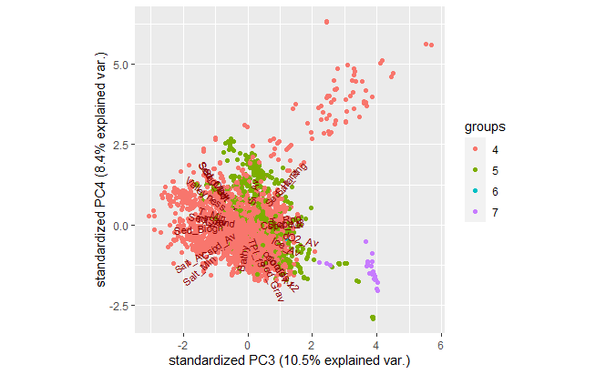

```r
ggbiplot(PCA.all,  choices=3:4, data=class.env.naomit, ellipse=F, groups=factor(class.env.naomit$level2), color=factor(class.env.naomit$level2))
```

#level2 with temp salinity

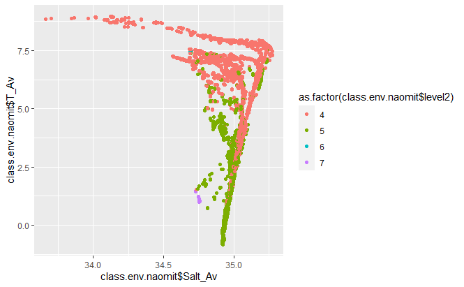

```r
## TS
 ggplot(class.env.naomit, aes(class.env.naomit$Salt_Av,class.env.naomit$T_Av))+
    geom_point(data=class.env.naomit, aes(color=as.factor(class.env.naomit$level2)))

          ggsave("TS_lev2.pdf", width = 30, height = 20, units = "cm",  dpi = 300)
```

# CHECK subgroups

Need to find and replace the P number and the level each time then run all chunks below this line.

## Subset

```r
#class.env.subs<-subset(class.env,is.na(class))
class.env.subs<-subset(class.env,class=="P2")
```

## Plots

NB you need to find and replace x= for the appropriate level

Depth (Bathy)

```r
png("U:/Mareano/VIDEOLAB/VIDEO DATA/200m_scale_species_by_sample/Data_Delivery_2021/outputs/Paal class subgroup tables/P2/bathy_P2.png",width = 1200, height = 500, units = "px")
ggplot(class.env.subs, aes(x=level9, y=Bathy))+
  geom_boxplot()
dev.off()
```

Temp Av (T_Av)

```r
png("U:/Mareano/VIDEOLAB/VIDEO DATA/200m_scale_species_by_sample/Data_Delivery_2021/outputs/Paal class subgroup tables/P2/T_Av_P2.png",width = 1200, height = 500, units = "px")
ggplot(class.env.subs, aes(x=level9, y=T_Av))+
  geom_boxplot()
dev.off()
```

Temp Min (T_Min)

```r
png("U:/Mareano/VIDEOLAB/VIDEO DATA/200m_scale_species_by_sample/Data_Delivery_2021/outputs/Paal class subgroup tables/P2/T_Min_P2.png",width = 1200, height = 500, units = "px")
ggplot(class.env.subs, aes(x=level9, y=T_Min))+
  geom_boxplot()
dev.off()
```

Salt Av(Salt_Av)

```r
png("U:/Mareano/VIDEOLAB/VIDEO DATA/200m_scale_species_by_sample/Data_Delivery_2021/outputs/Paal class subgroup tables/P2/Salt_Av_P2.png",width = 1200, height = 500, units = "px")
ggplot(class.env.subs, aes(x=level9, y=Salt_Av))+
  geom_boxplot()
dev.off()
```

Salt Min (Salt_Min)

```r
png("U:/Mareano/VIDEOLAB/VIDEO DATA/200m_scale_species_by_sample/Data_Delivery_2021/outputs/Paal class subgroup tables/P2/Salt_Min_P2.png",width = 1200, height = 500, units = "px")
ggplot(class.env.subs, aes(x=level9, y=Salt_Min))+
  geom_boxplot()
dev.off()
```

SedMud (Sed_Mud)

```r
png("U:/Mareano/VIDEOLAB/VIDEO DATA/200m_scale_species_by_sample/Data_Delivery_2021/outputs/Paal class subgroup tables/P2/Sed_Mud_P2.png",width = 1200, height = 500, units = "px")
ggplot(class.env.subs, aes(x=level9, y=Sed_Mud))+
  geom_boxplot()
dev.off()
```

SedSand (Sed_Sand)

```r
png("U:/Mareano/VIDEOLAB/VIDEO DATA/200m_scale_species_by_sample/Data_Delivery_2021/outputs/Paal class subgroup tables/P2/Sed_Sand_P2.png",width = 1200, height = 500, units = "px")
ggplot(class.env.subs, aes(x=level9, y=Sed_Sand))+
  geom_boxplot()
dev.off()
```

SedGravel (Sed_Gravel)

```r
png("U:/Mareano/VIDEOLAB/VIDEO DATA/200m_scale_species_by_sample/Data_Delivery_2021/outputs/Paal class subgroup tables/P2/Sed_Gravel_P2.png",width = 1200, height = 500, units = "px")
ggplot(class.env.subs, aes(x=level9, y=Sed_Grav))+
  geom_boxplot()
dev.off()
```

Cspd_Av

```r
png("U:/Mareano/VIDEOLAB/VIDEO DATA/200m_scale_species_by_sample/Data_Delivery_2021/outputs/Paal class subgroup tables/P2/Cspd_Av_P2.png",width = 1200, height = 500, units = "px")
ggplot(class.env.subs, aes(x=level9, y=Cspd_Av))+
  geom_boxplot()
dev.off()
```

Cspd_Mx

```r
png("U:/Mareano/VIDEOLAB/VIDEO DATA/200m_scale_species_by_sample/Data_Delivery_2021/outputs/Paal class subgroup tables/P2/Cspd_Mx_P2.png",width = 1200, height = 500, units = "px")
ggplot(class.env.subs, aes(x=level9, y=Cspd_Mx))+
  geom_boxplot()
dev.off()
```

dO2_Av

```r
png("U:/Mareano/VIDEOLAB/VIDEO DATA/200m_scale_species_by_sample/Data_Delivery_2021/outputs/Paal class subgroup tables/P2/dO2_Av_P2.png",width = 1200, height = 500, units = "px")
ggplot(class.env.subs, aes(x=level9, y=dO2_Av))+
  geom_boxplot()
dev.off()
```

Valleyness

```r
png("U:/Mareano/VIDEOLAB/VIDEO DATA/200m_scale_species_by_sample/Data_Delivery_2021/outputs/Paal class subgroup tables/P2/Valleyness_P2.png",width = 1200, height = 500, units = "px")
ggplot(class.env.subs, aes(x=level9, y=Valleyness))+
  geom_boxplot()
dev.off()
```

TPI_f3

```r
png("U:/Mareano/VIDEOLAB/VIDEO DATA/200m_scale_species_by_sample/Data_Delivery_2021/outputs/Paal class subgroup tables/P2/TPI_f3_P2.png",width = 1200, height = 500, units = "px")
ggplot(class.env.subs, aes(x=level9, y=TPI_f3))+
  geom_boxplot()
dev.off()
```

Slope_3

```r
png("U:/Mareano/VIDEOLAB/VIDEO DATA/200m_scale_species_by_sample/Data_Delivery_2021/outputs/Paal class subgroup tables/P2/Slope_3_P2.png",width = 1200, height = 500, units = "px")
ggplot(class.env.subs, aes(x=level9, y=Slope_3))+
  geom_boxplot()
dev.off()
```

TxSav

```r
png("U:/Mareano/VIDEOLAB/VIDEO DATA/200m_scale_species_by_sample/Data_Delivery_2021/outputs/Paal class subgroup tables/P2/TxSav_P2.png",width = 1200, height = 500, units = "px")
ggplot(class.env.subs, aes(x=level9, y=TxSav))+
  geom_boxplot()
dev.off()
```

Sed_Biogn

```r
png("U:/Mareano/VIDEOLAB/VIDEO DATA/200m_scale_species_by_sample/Data_Delivery_2021/outputs/Paal class subgroup tables/P2/Sed_Biogn_P2.png",width = 1200, height = 500, units = "px")
ggplot(class.env.subs, aes(x=level9, y=Sed_Biogn))+
  geom_boxplot()
dev.off()
```

Sed_Clay

```r
png("U:/Mareano/VIDEOLAB/VIDEO DATA/200m_scale_species_by_sample/Data_Delivery_2021/outputs/Paal class subgroup tables/P2/Sed_Clay _P2.png",width = 1200, height = 500, units = "px")
ggplot(class.env.subs, aes(x=level9, y=Sed_Clay ))+
  geom_boxplot()
dev.off()
```

Sed_Hard

```r
png("U:/Mareano/VIDEOLAB/VIDEO DATA/200m_scale_species_by_sample/Data_Delivery_2021/outputs/Paal class subgroup tables/P2/Sed_Hard_P2.png",width = 1200, height = 500, units = "px")
ggplot(class.env.subs, aes(x=level9, y=Sed_Hard))+
  geom_boxplot()
dev.off()
```

Si_Av

```r
png("U:/Mareano/VIDEOLAB/VIDEO DATA/200m_scale_species_by_sample/Data_Delivery_2021/outputs/Paal class subgroup tables/P2/Si_Av_P2.png",width = 1200, height = 500, units = "px")
ggplot(class.env.subs, aes(x=level9, y=Si_Av))+
  geom_boxplot()
dev.off()
```

Ice_Av

```r
png("U:/Mareano/VIDEOLAB/VIDEO DATA/200m_scale_species_by_sample/Data_Delivery_2021/outputs/Paal class subgroup tables/P2/Ice_Av_P2.png",width = 1200, height = 500, units = "px")
ggplot(class.env.subs, aes(x=level9, y=Ice_Av))+
  geom_boxplot()
dev.off()
```